# Risk Factor Analysis

## Outcome Variable

**Outcome Variable:** wast_rec90d

## Predictor Variables

**Intervention Variable:** birthwt

**Adjustment Set:**

- arm
- sex
- W_mage
- meducyrs
- feducyrs
- vagbrth
- brthmon
- W_parity
- delta_W_mage
- delta_meducyrs
- delta_feducyrs
- delta_vagbrth
- delta_brthmon
- delta_W_parity

## Stratifying Variables

The analysis was stratified on these variable(s):

- agecat
- studyid
- country

## Data Summary

| agecat | studyid | country | birthwt | wast_rec90d | n_cell | n |
| --- | --- | --- | --- | --- | --- | --- |
| 0-24 months | ki0047075b-MAL-ED | BANGLADESH | Normal or high birthweight | 0 | 31 | 119 |
| 0-24 months | ki0047075b-MAL-ED | BANGLADESH | Normal or high birthweight | 1 | 46 | 119 |
| 0-24 months | ki0047075b-MAL-ED | BANGLADESH | Low birth weight | 0 | 13 | 119 |
| 0-24 months | ki0047075b-MAL-ED | BANGLADESH | Low birth weight | 1 | 29 | 119 |
| 0-24 months | ki0047075b-MAL-ED | BRAZIL | Normal or high birthweight | 0 | 5 | 23 |
| 0-24 months | ki0047075b-MAL-ED | BRAZIL | Normal or high birthweight | 1 | 16 | 23 |
| 0-24 months | ki0047075b-MAL-ED | BRAZIL | Low birth weight | 0 | 1 | 23 |
| 0-24 months | ki0047075b-MAL-ED | BRAZIL | Low birth weight | 1 | 1 | 23 |
| 0-24 months | ki0047075b-MAL-ED | INDIA | Normal or high birthweight | 0 | 44 | 166 |
| 0-24 months | ki0047075b-MAL-ED | INDIA | Normal or high birthweight | 1 | 76 | 166 |
| 0-24 months | ki0047075b-MAL-ED | INDIA | Low birth weight | 0 | 21 | 166 |
| 0-24 months | ki0047075b-MAL-ED | INDIA | Low birth weight | 1 | 25 | 166 |
| 0-24 months | ki0047075b-MAL-ED | NEPAL | Normal or high birthweight | 0 | 12 | 85 |
| 0-24 months | ki0047075b-MAL-ED | NEPAL | Normal or high birthweight | 1 | 55 | 85 |
| 0-24 months | ki0047075b-MAL-ED | NEPAL | Low birth weight | 0 | 4 | 85 |
| 0-24 months | ki0047075b-MAL-ED | NEPAL | Low birth weight | 1 | 14 | 85 |
| 0-24 months | ki0047075b-MAL-ED | PERU | Normal or high birthweight | 0 | 3 | 34 |
| 0-24 months | ki0047075b-MAL-ED | PERU | Normal or high birthweight | 1 | 22 | 34 |
| 0-24 months | ki0047075b-MAL-ED | PERU | Low birth weight | 0 | 3 | 34 |
| 0-24 months | ki0047075b-MAL-ED | PERU | Low birth weight | 1 | 6 | 34 |
| 0-24 months | ki0047075b-MAL-ED | SOUTH AFRICA | Normal or high birthweight | 0 | 16 | 83 |
| 0-24 months | ki0047075b-MAL-ED | SOUTH AFRICA | Normal or high birthweight | 1 | 52 | 83 |
| 0-24 months | ki0047075b-MAL-ED | SOUTH AFRICA | Low birth weight | 0 | 1 | 83 |
| 0-24 months | ki0047075b-MAL-ED | SOUTH AFRICA | Low birth weight | 1 | 14 | 83 |
| 0-24 months | ki0047075b-MAL-ED | TANZANIA, UNITED REPUBLIC OF | Normal or high birthweight | 0 | 3 | 24 |
| 0-24 months | ki0047075b-MAL-ED | TANZANIA, UNITED REPUBLIC OF | Normal or high birthweight | 1 | 19 | 24 |
| 0-24 months | ki0047075b-MAL-ED | TANZANIA, UNITED REPUBLIC OF | Low birth weight | 0 | 0 | 24 |
| 0-24 months | ki0047075b-MAL-ED | TANZANIA, UNITED REPUBLIC OF | Low birth weight | 1 | 2 | 24 |
| 0-24 months | ki1000108-CMC-V-BCS-2002 | INDIA | Normal or high birthweight | 0 | 97 | 326 |
| 0-24 months | ki1000108-CMC-V-BCS-2002 | INDIA | Normal or high birthweight | 1 | 175 | 326 |

[output cut: 298 more lines]

The following strata were considered:

- agecat: 0-24 months, studyid: ki0047075b-MAL-ED, country: BANGLADESH
- agecat: 0-24 months, studyid: ki0047075b-MAL-ED, country: BRAZIL
- agecat: 0-24 months, studyid: ki0047075b-MAL-ED, country: INDIA
- agecat: 0-24 months, studyid: ki0047075b-MAL-ED, country: NEPAL
- agecat: 0-24 months, studyid: ki0047075b-MAL-ED, country: PERU
- agecat: 0-24 months, studyid: ki0047075b-MAL-ED, country: SOUTH AFRICA
- agecat: 0-24 months, studyid: ki0047075b-MAL-ED, country: TANZANIA, UNITED REPUBLIC OF
- agecat: 0-24 months, studyid: ki1000108-CMC-V-BCS-2002, country: INDIA
- agecat: 0-24 months, studyid: ki1000108-IRC, country: INDIA
- agecat: 0-24 months, studyid: ki1000109-EE, country: PAKISTAN
- agecat: 0-24 months, studyid: ki1000109-ResPak, country: PAKISTAN
- agecat: 0-24 months, studyid: ki1000304b-SAS-CompFeed, country: INDIA
- agecat: 0-24 months, studyid: ki1017093-NIH-Birth, country: BANGLADESH
- agecat: 0-24 months, studyid: ki1017093b-PROVIDE, country: BANGLADESH
- agecat: 0-24 months, studyid: ki1017093c-NIH-Crypto, country: BANGLADESH
- agecat: 0-24 months, studyid: ki1066203-TanzaniaChild2, country: TANZANIA, UNITED REPUBLIC OF
- agecat: 0-24 months, studyid: ki1101329-Keneba, country: GAMBIA
- agecat: 0-24 months, studyid: ki1114097-CMIN, country: BANGLADESH
- agecat: 0-24 months, studyid: ki1114097-CMIN, country: BRAZIL
- agecat: 0-24 months, studyid: ki1114097-CMIN, country: GUINEA-BISSAU
- agecat: 0-24 months, studyid: ki1114097-CMIN, country: PERU
- agecat: 0-24 months, studyid: ki1119695-PROBIT, country: BELARUS
- agecat: 0-24 months, studyid: ki1126311-ZVITAMBO, country: ZIMBABWE
- agecat: 0-24 months, studyid: ki1135781-COHORTS, country: GUATEMALA
- agecat: 0-24 months, studyid: ki1135781-COHORTS, country: INDIA
- agecat: 0-24 months, studyid: ki1135781-COHORTS, country: PHILIPPINES
- agecat: 0-24 months, studyid: kiGH5241-JiVitA-3, country: BANGLADESH
- agecat: 0-24 months, studyid: kiGH5241-JiVitA-4, country: BANGLADESH
- agecat: 0-6 months, studyid: ki0047075b-MAL-ED, country: BANGLADESH
- agecat: 0-6 months, studyid: ki0047075b-MAL-ED, country: BRAZIL
- agecat: 0-6 months, studyid: ki0047075b-MAL-ED, country: INDIA
- agecat: 0-6 months, studyid: ki0047075b-MAL-ED, country: NEPAL
- agecat: 0-6 months, studyid: ki0047075b-MAL-ED, country: PERU
- agecat: 0-6 months, studyid: ki0047075b-MAL-ED, country: SOUTH AFRICA
- agecat: 0-6 months, studyid: ki0047075b-MAL-ED, country: TANZANIA, UNITED REPUBLIC OF
- agecat: 0-6 months, studyid: ki1000108-CMC-V-BCS-2002, country: INDIA
- agecat: 0-6 months, studyid: ki1000108-IRC, country: INDIA
- agecat: 0-6 months, studyid: ki1000109-EE, country: PAKISTAN
- agecat: 0-6 months, studyid: ki1000109-ResPak, country: PAKISTAN
- agecat: 0-6 months, studyid: ki1000304b-SAS-CompFeed, country: INDIA
- agecat: 0-6 months, studyid: ki1017093-NIH-Birth, country: BANGLADESH
- agecat: 0-6 months, studyid: ki1017093b-PROVIDE, country: BANGLADESH
- agecat: 0-6 months, studyid: ki1017093c-NIH-Crypto, country: BANGLADESH
- agecat: 0-6 months, studyid: ki1066203-TanzaniaChild2, country: TANZANIA, UNITED REPUBLIC OF
- agecat: 0-6 months, studyid: ki1101329-Keneba, country: GAMBIA
- agecat: 0-6 months, studyid: ki1114097-CMIN, country: BANGLADESH
- agecat: 0-6 months, studyid: ki1114097-CMIN, country: BRAZIL
- agecat: 0-6 months, studyid: ki1114097-CMIN, country: GUINEA-BISSAU
- agecat: 0-6 months, studyid: ki1114097-CMIN, country: PERU
- agecat: 0-6 months, studyid: ki1119695-PROBIT, country: BELARUS
- agecat: 0-6 months, studyid: ki1126311-ZVITAMBO, country: ZIMBABWE
- agecat: 0-6 months, studyid: ki1135781-COHORTS, country: GUATEMALA
- agecat: 0-6 months, studyid: ki1135781-COHORTS, country: INDIA
- agecat: 0-6 months, studyid: ki1135781-COHORTS, country: PHILIPPINES
- agecat: 0-6 months, studyid: kiGH5241-JiVitA-3, country: BANGLADESH
- agecat: 0-6 months, studyid: kiGH5241-JiVitA-4, country: BANGLADESH
- agecat: 6-24 months, studyid: ki0047075b-MAL-ED, country: BANGLADESH
- agecat: 6-24 months, studyid: ki0047075b-MAL-ED, country: BRAZIL
- agecat: 6-24 months, studyid: ki0047075b-MAL-ED, country: INDIA
- agecat: 6-24 months, studyid: ki0047075b-MAL-ED, country: NEPAL
- agecat: 6-24 months, studyid: ki0047075b-MAL-ED, country: PERU
- agecat: 6-24 months, studyid: ki0047075b-MAL-ED, country: SOUTH AFRICA
- agecat: 6-24 months, studyid: ki0047075b-MAL-ED, country: TANZANIA, UNITED REPUBLIC OF
- agecat: 6-24 months, studyid: ki1000108-CMC-V-BCS-2002, country: INDIA
- agecat: 6-24 months, studyid: ki1000108-IRC, country: INDIA
- agecat: 6-24 months, studyid: ki1000109-EE, country: PAKISTAN
- agecat: 6-24 months, studyid: ki1000109-ResPak, country: PAKISTAN
- agecat: 6-24 months, studyid: ki1000304b-SAS-CompFeed, country: INDIA
- agecat: 6-24 months, studyid: ki1017093-NIH-Birth, country: BANGLADESH
- agecat: 6-24 months, studyid: ki1017093b-PROVIDE, country: BANGLADESH
- agecat: 6-24 months, studyid: ki1017093c-NIH-Crypto, country: BANGLADESH
- agecat: 6-24 months, studyid: ki1066203-TanzaniaChild2, country: TANZANIA, UNITED REPUBLIC OF
- agecat: 6-24 months, studyid: ki1101329-Keneba, country: GAMBIA
- agecat: 6-24 months, studyid: ki1114097-CMIN, country: BRAZIL
- agecat: 6-24 months, studyid: ki1114097-CMIN, country: PERU
- agecat: 6-24 months, studyid: ki1119695-PROBIT, country: BELARUS
- agecat: 6-24 months, studyid: ki1126311-ZVITAMBO, country: ZIMBABWE
- agecat: 6-24 months, studyid: ki1135781-COHORTS, country: GUATEMALA
- agecat: 6-24 months, studyid: ki1135781-COHORTS, country: INDIA
- agecat: 6-24 months, studyid: ki1135781-COHORTS, country: PHILIPPINES
- agecat: 6-24 months, studyid: kiGH5241-JiVitA-3, country: BANGLADESH
- agecat: 6-24 months, studyid: kiGH5241-JiVitA-4, country: BANGLADESH

### Dropped Strata

Some strata were dropped due to rare outcomes:

- agecat: 0-24 months, studyid: ki0047075b-MAL-ED, country: BRAZIL
- agecat: 0-24 months, studyid: ki0047075b-MAL-ED, country: NEPAL
- agecat: 0-24 months, studyid: ki0047075b-MAL-ED, country: PERU
- agecat: 0-24 months, studyid: ki0047075b-MAL-ED, country: SOUTH AFRICA
- agecat: 0-24 months, studyid: ki0047075b-MAL-ED, country: TANZANIA, UNITED REPUBLIC OF
- agecat: 0-24 months, studyid: ki1000109-ResPak, country: PAKISTAN
- agecat: 0-24 months, studyid: ki1114097-CMIN, country: BANGLADESH
- agecat: 0-24 months, studyid: ki1114097-CMIN, country: BRAZIL
- agecat: 0-24 months, studyid: ki1114097-CMIN, country: GUINEA-BISSAU
- agecat: 0-24 months, studyid: ki1114097-CMIN, country: PERU
- agecat: 0-24 months, studyid: ki1119695-PROBIT, country: BELARUS
- agecat: 0-6 months, studyid: ki0047075b-MAL-ED, country: BANGLADESH
- agecat: 0-6 months, studyid: ki0047075b-MAL-ED, country: BRAZIL
- agecat: 0-6 months, studyid: ki0047075b-MAL-ED, country: NEPAL
- agecat: 0-6 months, studyid: ki0047075b-MAL-ED, country: PERU
- agecat: 0-6 months, studyid: ki0047075b-MAL-ED, country: SOUTH AFRICA
- agecat: 0-6 months, studyid: ki0047075b-MAL-ED, country: TANZANIA, UNITED REPUBLIC OF
- agecat: 0-6 months, studyid: ki1000109-ResPak, country: PAKISTAN
- agecat: 0-6 months, studyid: ki1114097-CMIN, country: BANGLADESH
- agecat: 0-6 months, studyid: ki1114097-CMIN, country: BRAZIL
- agecat: 0-6 months, studyid: ki1114097-CMIN, country: GUINEA-BISSAU
- agecat: 0-6 months, studyid: ki1114097-CMIN, country: PERU
- agecat: 0-6 months, studyid: ki1119695-PROBIT, country: BELARUS
- agecat: 6-24 months, studyid: ki0047075b-MAL-ED, country: BRAZIL
- agecat: 6-24 months, studyid: ki0047075b-MAL-ED, country: NEPAL
- agecat: 6-24 months, studyid: ki0047075b-MAL-ED, country: PERU
- agecat: 6-24 months, studyid: ki0047075b-MAL-ED, country: SOUTH AFRICA
- agecat: 6-24 months, studyid: ki0047075b-MAL-ED, country: TANZANIA, UNITED REPUBLIC OF
- agecat: 6-24 months, studyid: ki1000109-ResPak, country: PAKISTAN
- agecat: 6-24 months, studyid: ki1017093c-NIH-Crypto, country: BANGLADESH
- agecat: 6-24 months, studyid: ki1114097-CMIN, country: BRAZIL
- agecat: 6-24 months, studyid: ki1114097-CMIN, country: PERU
- agecat: 6-24 months, studyid: ki1119695-PROBIT, country: BELARUS
- agecat: 6-24 months, studyid: ki1135781-COHORTS, country: GUATEMALA
- agecat: 6-24 months, studyid: ki1135781-COHORTS, country: INDIA
- agecat: 6-24 months, studyid: kiGH5241-JiVitA-3, country: BANGLADESH

## Methods Detail

We’re interested in the causal parameters $E[Y_a]$ for all values of $a \in \mathcal{A}$. These parameters represent the mean outcome if, possibly contrary to fact, we intervened to set all units to have $A=a$. Under the randomization and positivity assumptions, these are identified by the statistical parameters $\psi_a=E_W[E_{Y|A,W}(Y|A=a,W)]$. In addition, we’re interested in the mean of $Y$, $E[Y]$ under no intervention (the observed mean). We will estimate these parameters by using SuperLearner to fit the relevant likelihood factors – $E_{Y|A,W}(Y|A=a,W)$ and $p(A=a|W)$, and then updating our likelihood fit using a joint TMLE.

For unadjusted analyses ($W=\{\}$), initial likelihoods were estimated using Lrnr_glm to estimate the simple $E(Y|A)$ and Lrnr_mean to estimate $p(A)$. For adjusted analyses, a small library containing Lrnr_glmnet, Lrnr_xgboost, and Lrnr_mean was used.

Having estimated these parameters, we will then use the delta method to estimate relative risks and attributable risks relative to a prespecified baseline level of $A$.

# Results Detail

## Results Plots

[figure not shown]

[figure not shown]

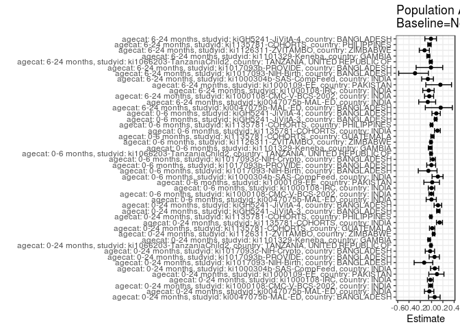

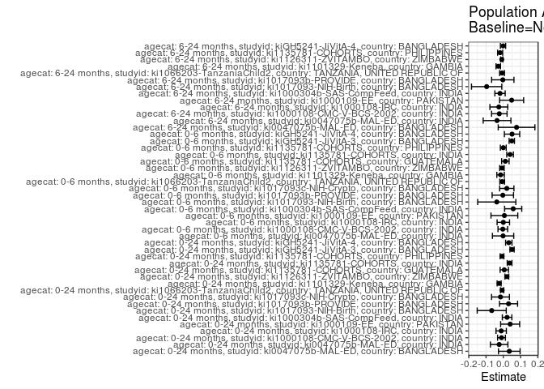

## Results Table

### Parameter: TSM

| agecat | studyid | country | intervention_level | baseline_level | estimate | ci_lower | ci_upper |
| --- | --- | --- | --- | --- | --- | --- | --- |
| 0-24 months | ki0047075b-MAL-ED | BANGLADESH | Normal or high birthweight | NA | 0.5956928 | 0.4729255 | 0.7184602 |
| 0-24 months | ki0047075b-MAL-ED | BANGLADESH | Low birth weight | NA | 0.7040993 | 0.5865498 | 0.8216488 |
| 0-24 months | ki0047075b-MAL-ED | INDIA | Normal or high birthweight | NA | 0.6324680 | 0.5335722 | 0.7313639 |
| 0-24 months | ki0047075b-MAL-ED | INDIA | Low birth weight | NA | 0.5347595 | 0.3818681 | 0.6876509 |
| 0-24 months | ki1000108-CMC-V-BCS-2002 | INDIA | Normal or high birthweight | NA | 0.6424101 | 0.5800265 | 0.7047938 |
| 0-24 months | ki1000108-CMC-V-BCS-2002 | INDIA | Low birth weight | NA | 0.5679662 | 0.4457215 | 0.6902109 |
| 0-24 months | ki1000108-IRC | INDIA | Normal or high birthweight | NA | 0.6011183 | 0.5394236 | 0.6628130 |
| 0-24 months | ki1000108-IRC | INDIA | Low birth weight | NA | 0.5614755 | 0.4612630 | 0.6616879 |
| 0-24 months | ki1000109-EE | PAKISTAN | Normal or high birthweight | NA | 0.3767587 | 0.2891033 | 0.4644141 |
| 0-24 months | ki1000109-EE | PAKISTAN | Low birth weight | NA | 0.4466032 | 0.3427370 | 0.5504695 |
| 0-24 months | ki1000304b-SAS-CompFeed | INDIA | Normal or high birthweight | NA | 0.3604245 | 0.3138992 | 0.4069498 |
| 0-24 months | ki1000304b-SAS-CompFeed | INDIA | Low birth weight | NA | 0.4155854 | 0.3623007 | 0.4688701 |
| 0-24 months | ki1017093-NIH-Birth | BANGLADESH | Normal or high birthweight | NA | 0.5789616 | 0.4593889 | 0.6985343 |
| 0-24 months | ki1017093-NIH-Birth | BANGLADESH | Low birth weight | NA | 0.4687755 | 0.3519919 | 0.5855591 |
| 0-24 months | ki1017093b-PROVIDE | BANGLADESH | Normal or high birthweight | NA | 0.5526837 | 0.4715991 | 0.6337684 |
| 0-24 months | ki1017093b-PROVIDE | BANGLADESH | Low birth weight | NA | 0.6108321 | 0.5317693 | 0.6898948 |
| 0-24 months | ki1017093c-NIH-Crypto | BANGLADESH | Normal or high birthweight | NA | 0.6401725 | 0.5582402 | 0.7221048 |
| 0-24 months | ki1017093c-NIH-Crypto | BANGLADESH | Low birth weight | NA | 0.6262695 | 0.5563437 | 0.6961954 |
| 0-24 months | ki1066203-TanzaniaChild2 | TANZANIA, UNITED REPUBLIC OF | Normal or high birthweight | NA | 0.6326984 | 0.5937371 | 0.6716598 |
| 0-24 months | ki1066203-TanzaniaChild2 | TANZANIA, UNITED REPUBLIC OF | Low birth weight | NA | 0.5311066 | 0.3488645 | 0.7133487 |
| 0-24 months | ki1101329-Keneba | GAMBIA | Normal or high birthweight | NA | 0.5761307 | 0.5438157 | 0.6084457 |
| 0-24 months | ki1101329-Keneba | GAMBIA | Low birth weight | NA | 0.3609270 | 0.2737500 | 0.4481040 |
| 0-24 months | ki1126311-ZVITAMBO | ZIMBABWE | Normal or high birthweight | NA | 0.5244318 | 0.5042684 | 0.5445953 |
| 0-24 months | ki1126311-ZVITAMBO | ZIMBABWE | Low birth weight | NA | 0.5903472 | 0.5619832 | 0.6187112 |
| 0-24 months | ki1135781-COHORTS | GUATEMALA | Normal or high birthweight | NA | 0.5099066 | 0.4493849 | 0.5704282 |
| 0-24 months | ki1135781-COHORTS | GUATEMALA | Low birth weight | NA | 0.5417042 | 0.3826831 | 0.7007253 |
| 0-24 months | ki1135781-COHORTS | INDIA | Normal or high birthweight | NA | 0.2196749 | 0.1986742 | 0.2406755 |
| 0-24 months | ki1135781-COHORTS | INDIA | Low birth weight | NA | 0.3169853 | 0.2878516 | 0.3461190 |
| 0-24 months | ki1135781-COHORTS | PHILIPPINES | Normal or high birthweight | NA | 0.6144670 | 0.5865017 | 0.6424324 |
| 0-24 months | ki1135781-COHORTS | PHILIPPINES | Low birth weight | NA | 0.5755498 | 0.5236068 | 0.6274927 |

[output cut: 62 more lines]

### Parameter: E(Y)

| agecat | studyid | country | intervention_level | baseline_level | estimate | ci_lower | ci_upper |
| --- | --- | --- | --- | --- | --- | --- | --- |
| 0-24 months | ki0047075b-MAL-ED | BANGLADESH | NA | NA | 0.6302521 | 0.5419905 | 0.7185137 |
| 0-24 months | ki0047075b-MAL-ED | INDIA | NA | NA | 0.6084337 | 0.5263180 | 0.6905495 |
| 0-24 months | ki1000108-CMC-V-BCS-2002 | INDIA | NA | NA | 0.6319018 | 0.5759256 | 0.6878781 |
| 0-24 months | ki1000108-IRC | INDIA | NA | NA | 0.5888325 | 0.5365454 | 0.6411196 |
| 0-24 months | ki1000109-EE | PAKISTAN | NA | NA | 0.4163424 | 0.3511349 | 0.4815500 |
| 0-24 months | ki1000304b-SAS-CompFeed | INDIA | NA | NA | 0.3822441 | 0.3470621 | 0.4174262 |
| 0-24 months | ki1017093-NIH-Birth | BANGLADESH | NA | NA | 0.5117647 | 0.4302715 | 0.5932579 |
| 0-24 months | ki1017093b-PROVIDE | BANGLADESH | NA | NA | 0.5830619 | 0.5262762 | 0.6398476 |
| 0-24 months | ki1017093c-NIH-Crypto | BANGLADESH | NA | NA | 0.6237942 | 0.5698223 | 0.6777662 |
| 0-24 months | ki1066203-TanzaniaChild2 | TANZANIA, UNITED REPUBLIC OF | NA | NA | 0.6258890 | 0.5879514 | 0.6638267 |
| 0-24 months | ki1101329-Keneba | GAMBIA | NA | NA | 0.5519802 | 0.5212828 | 0.5826776 |
| 0-24 months | ki1126311-ZVITAMBO | ZIMBABWE | NA | NA | 0.5451233 | 0.5286432 | 0.5616034 |
| 0-24 months | ki1135781-COHORTS | GUATEMALA | NA | NA | 0.5156250 | 0.4594779 | 0.5717721 |
| 0-24 months | ki1135781-COHORTS | INDIA | NA | NA | 0.2559618 | 0.2388022 | 0.2731215 |
| 0-24 months | ki1135781-COHORTS | PHILIPPINES | NA | NA | 0.6069712 | 0.5823178 | 0.6316245 |
| 0-24 months | kiGH5241-JiVitA-3 | BANGLADESH | NA | NA | 0.4229395 | 0.4118068 | 0.4340723 |
| 0-24 months | kiGH5241-JiVitA-4 | BANGLADESH | NA | NA | 0.2783678 | 0.2569102 | 0.2998254 |
| 0-6 months | ki0047075b-MAL-ED | INDIA | NA | NA | 0.6883117 | 0.5823564 | 0.7942670 |
| 0-6 months | ki1000108-CMC-V-BCS-2002 | INDIA | NA | NA | 0.6748768 | 0.6092233 | 0.7405304 |
| 0-6 months | ki1000108-IRC | INDIA | NA | NA | 0.6359833 | 0.5734338 | 0.6985327 |
| 0-6 months | ki1000109-EE | PAKISTAN | NA | NA | 0.5648148 | 0.4692893 | 0.6603404 |
| 0-6 months | ki1000304b-SAS-CompFeed | INDIA | NA | NA | 0.5147059 | 0.4610948 | 0.5683169 |
| 0-6 months | ki1017093-NIH-Birth | BANGLADESH | NA | NA | 0.6703297 | 0.5732092 | 0.7674502 |
| 0-6 months | ki1017093b-PROVIDE | BANGLADESH | NA | NA | 0.7880435 | 0.7295878 | 0.8464992 |
| 0-6 months | ki1017093c-NIH-Crypto | BANGLADESH | NA | NA | 0.8939394 | 0.8505280 | 0.9373508 |
| 0-6 months | ki1066203-TanzaniaChild2 | TANZANIA, UNITED REPUBLIC OF | NA | NA | 0.7014925 | 0.6517566 | 0.7512285 |
| 0-6 months | ki1101329-Keneba | GAMBIA | NA | NA | 0.6616766 | 0.6110579 | 0.7122953 |
| 0-6 months | ki1126311-ZVITAMBO | ZIMBABWE | NA | NA | 0.7439364 | 0.7268897 | 0.7609830 |
| 0-6 months | ki1135781-COHORTS | GUATEMALA | NA | NA | 0.7619048 | 0.7043195 | 0.8194900 |
| 0-6 months | ki1135781-COHORTS | INDIA | NA | NA | 0.3750728 | 0.3521661 | 0.3979795 |
| 0-6 months | ki1135781-COHORTS | PHILIPPINES | NA | NA | 0.7372654 | 0.7055895 | 0.7689413 |
| 0-6 months | kiGH5241-JiVitA-3 | BANGLADESH | NA | NA | 0.6760414 | 0.6627031 | 0.6893798 |
| 0-6 months | kiGH5241-JiVitA-4 | BANGLADESH | NA | NA | 0.6058824 | 0.5634305 | 0.6483342 |
| 6-24 months | ki0047075b-MAL-ED | BANGLADESH | NA | NA | 0.4745763 | 0.3430726 | 0.6060800 |
| 6-24 months | ki0047075b-MAL-ED | INDIA | NA | NA | 0.5393258 | 0.4214529 | 0.6571988 |
| 6-24 months | ki1000108-CMC-V-BCS-2002 | INDIA | NA | NA | 0.5609756 | 0.4682842 | 0.6536670 |
| 6-24 months | ki1000108-IRC | INDIA | NA | NA | 0.5161290 | 0.4322562 | 0.6000019 |
| 6-24 months | ki1000109-EE | PAKISTAN | NA | NA | 0.3087248 | 0.2336906 | 0.3837591 |
| 6-24 months | ki1000304b-SAS-CompFeed | INDIA | NA | NA | 0.2866242 | 0.2446853 | 0.3285631 |
| 6-24 months | ki1017093-NIH-Birth | BANGLADESH | NA | NA | 0.3291139 | 0.2187678 | 0.4394600 |
| 6-24 months | ki1017093b-PROVIDE | BANGLADESH | NA | NA | 0.2764228 | 0.1950773 | 0.3577682 |
| 6-24 months | ki1066203-TanzaniaChild2 | TANZANIA, UNITED REPUBLIC OF | NA | NA | 0.5570652 | 0.5044805 | 0.6096499 |
| 6-24 months | ki1101329-Keneba | GAMBIA | NA | NA | 0.5102506 | 0.4747348 | 0.5457664 |
| 6-24 months | ki1126311-ZVITAMBO | ZIMBABWE | NA | NA | 0.0702754 | 0.0549673 | 0.0855835 |
| 6-24 months | ki1135781-COHORTS | PHILIPPINES | NA | NA | 0.5010893 | 0.4669869 | 0.5351918 |
| 6-24 months | kiGH5241-JiVitA-4 | BANGLADESH | NA | NA | 0.1477717 | 0.1285384 | 0.1670050 |

### Parameter: RR

| agecat | studyid | country | intervention_level | baseline_level | estimate | ci_lower | ci_upper |
| --- | --- | --- | --- | --- | --- | --- | --- |
| 0-24 months | ki0047075b-MAL-ED | BANGLADESH | Normal or high birthweight | Normal or high birthweight | 1.0000000 | 1.0000000 | 1.0000000 |
| 0-24 months | ki0047075b-MAL-ED | BANGLADESH | Low birth weight | Normal or high birthweight | 1.1819838 | 0.9039262 | 1.5455749 |
| 0-24 months | ki0047075b-MAL-ED | INDIA | Normal or high birthweight | Normal or high birthweight | 1.0000000 | 1.0000000 | 1.0000000 |
| 0-24 months | ki0047075b-MAL-ED | INDIA | Low birth weight | Normal or high birthweight | 0.8455123 | 0.6093114 | 1.1732770 |
| 0-24 months | ki1000108-CMC-V-BCS-2002 | INDIA | Normal or high birthweight | Normal or high birthweight | 1.0000000 | 1.0000000 | 1.0000000 |
| 0-24 months | ki1000108-CMC-V-BCS-2002 | INDIA | Low birth weight | Normal or high birthweight | 0.8841177 | 0.6988348 | 1.1185249 |
| 0-24 months | ki1000108-IRC | INDIA | Normal or high birthweight | Normal or high birthweight | 1.0000000 | 1.0000000 | 1.0000000 |
| 0-24 months | ki1000108-IRC | INDIA | Low birth weight | Normal or high birthweight | 0.9340515 | 0.7600954 | 1.1478194 |
| 0-24 months | ki1000109-EE | PAKISTAN | Normal or high birthweight | Normal or high birthweight | 1.0000000 | 1.0000000 | 1.0000000 |
| 0-24 months | ki1000109-EE | PAKISTAN | Low birth weight | Normal or high birthweight | 1.1853827 | 0.8535991 | 1.6461265 |
| 0-24 months | ki1000304b-SAS-CompFeed | INDIA | Normal or high birthweight | Normal or high birthweight | 1.0000000 | 1.0000000 | 1.0000000 |
| 0-24 months | ki1000304b-SAS-CompFeed | INDIA | Low birth weight | Normal or high birthweight | 1.1530442 | 0.9614190 | 1.3828632 |
| 0-24 months | ki1017093-NIH-Birth | BANGLADESH | Normal or high birthweight | Normal or high birthweight | 1.0000000 | 1.0000000 | 1.0000000 |
| 0-24 months | ki1017093-NIH-Birth | BANGLADESH | Low birth weight | Normal or high birthweight | 0.8096833 | 0.5840383 | 1.1225068 |
| 0-24 months | ki1017093b-PROVIDE | BANGLADESH | Normal or high birthweight | Normal or high birthweight | 1.0000000 | 1.0000000 | 1.0000000 |
| 0-24 months | ki1017093b-PROVIDE | BANGLADESH | Low birth weight | Normal or high birthweight | 1.1052109 | 0.9083524 | 1.3447327 |
| 0-24 months | ki1017093c-NIH-Crypto | BANGLADESH | Normal or high birthweight | Normal or high birthweight | 1.0000000 | 1.0000000 | 1.0000000 |
| 0-24 months | ki1017093c-NIH-Crypto | BANGLADESH | Low birth weight | Normal or high birthweight | 0.9782824 | 0.8253431 | 1.1595620 |
| 0-24 months | ki1066203-TanzaniaChild2 | TANZANIA, UNITED REPUBLIC OF | Normal or high birthweight | Normal or high birthweight | 1.0000000 | 1.0000000 | 1.0000000 |
| 0-24 months | ki1066203-TanzaniaChild2 | TANZANIA, UNITED REPUBLIC OF | Low birth weight | Normal or high birthweight | 0.8394309 | 0.5924010 | 1.1894717 |
| 0-24 months | ki1101329-Keneba | GAMBIA | Normal or high birthweight | Normal or high birthweight | 1.0000000 | 1.0000000 | 1.0000000 |
| 0-24 months | ki1101329-Keneba | GAMBIA | Low birth weight | Normal or high birthweight | 0.6264672 | 0.4889220 | 0.8027071 |
| 0-24 months | ki1126311-ZVITAMBO | ZIMBABWE | Normal or high birthweight | Normal or high birthweight | 1.0000000 | 1.0000000 | 1.0000000 |
| 0-24 months | ki1126311-ZVITAMBO | ZIMBABWE | Low birth weight | Normal or high birthweight | 1.1256892 | 1.0585584 | 1.1970772 |
| 0-24 months | ki1135781-COHORTS | GUATEMALA | Normal or high birthweight | Normal or high birthweight | 1.0000000 | 1.0000000 | 1.0000000 |
| 0-24 months | ki1135781-COHORTS | GUATEMALA | Low birth weight | Normal or high birthweight | 1.0623598 | 0.7737697 | 1.4585843 |
| 0-24 months | ki1135781-COHORTS | INDIA | Normal or high birthweight | Normal or high birthweight | 1.0000000 | 1.0000000 | 1.0000000 |
| 0-24 months | ki1135781-COHORTS | INDIA | Low birth weight | Normal or high birthweight | 1.4429749 | 1.2638529 | 1.6474834 |
| 0-24 months | ki1135781-COHORTS | PHILIPPINES | Normal or high birthweight | Normal or high birthweight | 1.0000000 | 1.0000000 | 1.0000000 |
| 0-24 months | ki1135781-COHORTS | PHILIPPINES | Low birth weight | Normal or high birthweight | 0.9366651 | 0.8468630 | 1.0359898 |

[output cut: 62 more lines]

### Parameter: PAR

| agecat | studyid | country | intervention_level | baseline_level | estimate | ci_lower | ci_upper |
| --- | --- | --- | --- | --- | --- | --- | --- |
| 0-24 months | ki0047075b-MAL-ED | BANGLADESH | Normal or high birthweight | NA | 0.0345593 | -0.0279392 | 0.0970577 |
| 0-24 months | ki0047075b-MAL-ED | INDIA | Normal or high birthweight | NA | -0.0240343 | -0.0746228 | 0.0265542 |
| 0-24 months | ki1000108-CMC-V-BCS-2002 | INDIA | Normal or high birthweight | NA | -0.0105083 | -0.0331674 | 0.0121509 |
| 0-24 months | ki1000108-IRC | INDIA | Normal or high birthweight | NA | -0.0122858 | -0.0422207 | 0.0176491 |
| 0-24 months | ki1000109-EE | PAKISTAN | Normal or high birthweight | NA | 0.0395837 | -0.0154205 | 0.0945879 |
| 0-24 months | ki1000304b-SAS-CompFeed | INDIA | Normal or high birthweight | NA | 0.0218197 | -0.0059130 | 0.0495523 |
| 0-24 months | ki1017093-NIH-Birth | BANGLADESH | Normal or high birthweight | NA | -0.0671969 | -0.1513339 | 0.0169401 |
| 0-24 months | ki1017093b-PROVIDE | BANGLADESH | Normal or high birthweight | NA | 0.0303782 | -0.0220451 | 0.0828014 |
| 0-24 months | ki1017093c-NIH-Crypto | BANGLADESH | Normal or high birthweight | NA | -0.0163783 | -0.0681125 | 0.0353558 |
| 0-24 months | ki1066203-TanzaniaChild2 | TANZANIA, UNITED REPUBLIC OF | Normal or high birthweight | NA | -0.0068094 | -0.0164671 | 0.0028483 |
| 0-24 months | ki1101329-Keneba | GAMBIA | Normal or high birthweight | NA | -0.0241505 | -0.0357491 | -0.0125519 |
| 0-24 months | ki1126311-ZVITAMBO | ZIMBABWE | Normal or high birthweight | NA | 0.0206915 | 0.0097080 | 0.0316750 |
| 0-24 months | ki1135781-COHORTS | GUATEMALA | Normal or high birthweight | NA | 0.0057184 | -0.0184437 | 0.0298806 |
| 0-24 months | ki1135781-COHORTS | INDIA | Normal or high birthweight | NA | 0.0362870 | 0.0226878 | 0.0498862 |
| 0-24 months | ki1135781-COHORTS | PHILIPPINES | Normal or high birthweight | NA | -0.0074959 | -0.0183653 | 0.0033736 |
| 0-24 months | kiGH5241-JiVitA-3 | BANGLADESH | Normal or high birthweight | NA | 0.0505643 | 0.0383269 | 0.0628017 |
| 0-24 months | kiGH5241-JiVitA-4 | BANGLADESH | Normal or high birthweight | NA | 0.0317519 | 0.0132974 | 0.0502063 |
| 0-6 months | ki0047075b-MAL-ED | INDIA | Normal or high birthweight | NA | -0.0013435 | -0.0630803 | 0.0603933 |
| 0-6 months | ki1000108-CMC-V-BCS-2002 | INDIA | Normal or high birthweight | NA | -0.0028389 | -0.0307463 | 0.0250685 |
| 0-6 months | ki1000108-IRC | INDIA | Normal or high birthweight | NA | 0.0000814 | -0.0359682 | 0.0361310 |
| 0-6 months | ki1000109-EE | PAKISTAN | Normal or high birthweight | NA | 0.0062222 | -0.0714055 | 0.0838498 |
| 0-6 months | ki1000304b-SAS-CompFeed | INDIA | Normal or high birthweight | NA | 0.0573607 | 0.0077917 | 0.1069298 |
| 0-6 months | ki1017093-NIH-Birth | BANGLADESH | Normal or high birthweight | NA | -0.0379073 | -0.1482904 | 0.0724758 |
| 0-6 months | ki1017093b-PROVIDE | BANGLADESH | Normal or high birthweight | NA | -0.0028060 | -0.0648072 | 0.0591952 |
| 0-6 months | ki1017093c-NIH-Crypto | BANGLADESH | Normal or high birthweight | NA | 0.0201530 | -0.0212303 | 0.0615363 |
| 0-6 months | ki1066203-TanzaniaChild2 | TANZANIA, UNITED REPUBLIC OF | Normal or high birthweight | NA | -0.0064440 | -0.0201935 | 0.0073055 |
| 0-6 months | ki1101329-Keneba | GAMBIA | Normal or high birthweight | NA | -0.0157438 | -0.0373978 | 0.0059101 |
| 0-6 months | ki1126311-ZVITAMBO | ZIMBABWE | Normal or high birthweight | NA | -0.0079898 | -0.0208835 | 0.0049039 |
| 0-6 months | ki1135781-COHORTS | GUATEMALA | Normal or high birthweight | NA | 0.0119048 | -0.0096709 | 0.0334804 |
| 0-6 months | ki1135781-COHORTS | INDIA | Normal or high birthweight | NA | 0.0391564 | 0.0199874 | 0.0583255 |
| 0-6 months | ki1135781-COHORTS | PHILIPPINES | Normal or high birthweight | NA | -0.0001884 | -0.0170634 | 0.0166866 |
| 0-6 months | kiGH5241-JiVitA-3 | BANGLADESH | Normal or high birthweight | NA | 0.0490820 | 0.0336494 | 0.0645146 |
| 0-6 months | kiGH5241-JiVitA-4 | BANGLADESH | Normal or high birthweight | NA | 0.0506827 | 0.0064187 | 0.0949467 |
| 6-24 months | ki0047075b-MAL-ED | BANGLADESH | Normal or high birthweight | NA | 0.0767871 | -0.0294447 | 0.1830190 |
| 6-24 months | ki0047075b-MAL-ED | INDIA | Normal or high birthweight | NA | -0.0362624 | -0.1165296 | 0.0440049 |
| 6-24 months | ki1000108-CMC-V-BCS-2002 | INDIA | Normal or high birthweight | NA | -0.0230774 | -0.0678829 | 0.0217280 |
| 6-24 months | ki1000108-IRC | INDIA | Normal or high birthweight | NA | -0.0259489 | -0.0776891 | 0.0257913 |
| 6-24 months | ki1000109-EE | PAKISTAN | Normal or high birthweight | NA | 0.0481931 | -0.0213875 | 0.1177736 |
| 6-24 months | ki1000304b-SAS-CompFeed | INDIA | Normal or high birthweight | NA | -0.0190089 | -0.0488445 | 0.0108267 |
| 6-24 months | ki1017093-NIH-Birth | BANGLADESH | Normal or high birthweight | NA | -0.0964180 | -0.1841562 | -0.0086798 |
| 6-24 months | ki1017093b-PROVIDE | BANGLADESH | Normal or high birthweight | NA | -0.0029848 | -0.0675963 | 0.0616267 |
| 6-24 months | ki1066203-TanzaniaChild2 | TANZANIA, UNITED REPUBLIC OF | Normal or high birthweight | NA | -0.0074047 | -0.0214410 | 0.0066316 |
| 6-24 months | ki1101329-Keneba | GAMBIA | Normal or high birthweight | NA | -0.0291425 | -0.0421566 | -0.0161284 |
| 6-24 months | ki1126311-ZVITAMBO | ZIMBABWE | Normal or high birthweight | NA | -0.0087665 | -0.0152510 | -0.0022820 |
| 6-24 months | ki1135781-COHORTS | PHILIPPINES | Normal or high birthweight | NA | -0.0184590 | -0.0330972 | -0.0038209 |
| 6-24 months | kiGH5241-JiVitA-4 | BANGLADESH | Normal or high birthweight | NA | -0.0016430 | -0.0167722 | 0.0134863 |

### Parameter: PAF

| agecat | studyid | country | intervention_level | baseline_level | estimate | ci_lower | ci_upper |
| --- | --- | --- | --- | --- | --- | --- | --- |
| 0-24 months | ki0047075b-MAL-ED | BANGLADESH | Normal or high birthweight | NA | 0.0548340 | -0.0526245 | 0.1513225 |
| 0-24 months | ki0047075b-MAL-ED | INDIA | Normal or high birthweight | NA | -0.0395019 | -0.1259158 | 0.0402797 |
| 0-24 months | ki1000108-CMC-V-BCS-2002 | INDIA | Normal or high birthweight | NA | -0.0166296 | -0.0530120 | 0.0184957 |
| 0-24 months | ki1000108-IRC | INDIA | Normal or high birthweight | NA | -0.0208647 | -0.0729153 | 0.0286608 |
| 0-24 months | ki1000109-EE | PAKISTAN | Normal or high birthweight | NA | 0.0950749 | -0.0491046 | 0.2194396 |
| 0-24 months | ki1000304b-SAS-CompFeed | INDIA | Normal or high birthweight | NA | 0.0570830 | -0.0189948 | 0.1274809 |
| 0-24 months | ki1017093-NIH-Birth | BANGLADESH | Normal or high birthweight | NA | -0.1313042 | -0.3087750 | 0.0221014 |
| 0-24 months | ki1017093b-PROVIDE | BANGLADESH | Normal or high birthweight | NA | 0.0521011 | -0.0429304 | 0.1384734 |
| 0-24 months | ki1017093c-NIH-Crypto | BANGLADESH | Normal or high birthweight | NA | -0.0262560 | -0.1121709 | 0.0530221 |
| 0-24 months | ki1066203-TanzaniaChild2 | TANZANIA, UNITED REPUBLIC OF | Normal or high birthweight | NA | -0.0108796 | -0.0264559 | 0.0044604 |
| 0-24 months | ki1101329-Keneba | GAMBIA | Normal or high birthweight | NA | -0.0437525 | -0.0652341 | -0.0227041 |
| 0-24 months | ki1126311-ZVITAMBO | ZIMBABWE | Normal or high birthweight | NA | 0.0379574 | 0.0175168 | 0.0579728 |
| 0-24 months | ki1135781-COHORTS | GUATEMALA | Normal or high birthweight | NA | 0.0110903 | -0.0368796 | 0.0568409 |
| 0-24 months | ki1135781-COHORTS | INDIA | Normal or high birthweight | NA | 0.1417671 | 0.0868852 | 0.1933505 |
| 0-24 months | ki1135781-COHORTS | PHILIPPINES | Normal or high birthweight | NA | -0.0123496 | -0.0303702 | 0.0053558 |
| 0-24 months | kiGH5241-JiVitA-3 | BANGLADESH | Normal or high birthweight | NA | 0.1195544 | 0.0900144 | 0.1481355 |
| 0-24 months | kiGH5241-JiVitA-4 | BANGLADESH | Normal or high birthweight | NA | 0.1140645 | 0.0446473 | 0.1784376 |
| 0-6 months | ki0047075b-MAL-ED | INDIA | Normal or high birthweight | NA | -0.0019519 | -0.0957926 | 0.0838526 |
| 0-6 months | ki1000108-CMC-V-BCS-2002 | INDIA | Normal or high birthweight | NA | -0.0042065 | -0.0464272 | 0.0363107 |
| 0-6 months | ki1000108-IRC | INDIA | Normal or high birthweight | NA | 0.0001280 | -0.0581928 | 0.0552345 |
| 0-6 months | ki1000109-EE | PAKISTAN | Normal or high birthweight | NA | 0.0110163 | -0.1365057 | 0.1393895 |
| 0-6 months | ki1000304b-SAS-CompFeed | INDIA | Normal or high birthweight | NA | 0.1114437 | 0.0088220 | 0.2034404 |
| 0-6 months | ki1017093-NIH-Birth | BANGLADESH | Normal or high birthweight | NA | -0.0565502 | -0.2357052 | 0.0966305 |
| 0-6 months | ki1017093b-PROVIDE | BANGLADESH | Normal or high birthweight | NA | -0.0035608 | -0.0853910 | 0.0721001 |
| 0-6 months | ki1017093c-NIH-Crypto | BANGLADESH | Normal or high birthweight | NA | 0.0225440 | -0.0250709 | 0.0679472 |
| 0-6 months | ki1066203-TanzaniaChild2 | TANZANIA, UNITED REPUBLIC OF | Normal or high birthweight | NA | -0.0091861 | -0.0290217 | 0.0102672 |
| 0-6 months | ki1101329-Keneba | GAMBIA | Normal or high birthweight | NA | -0.0237938 | -0.0571866 | 0.0085442 |
| 0-6 months | ki1126311-ZVITAMBO | ZIMBABWE | Normal or high birthweight | NA | -0.0107399 | -0.0282302 | 0.0064529 |
| 0-6 months | ki1135781-COHORTS | GUATEMALA | Normal or high birthweight | NA | 0.0156250 | -0.0132322 | 0.0436603 |
| 0-6 months | ki1135781-COHORTS | INDIA | Normal or high birthweight | NA | 0.1043969 | 0.0517664 | 0.1541061 |
| 0-6 months | ki1135781-COHORTS | PHILIPPINES | Normal or high birthweight | NA | -0.0002555 | -0.0234079 | 0.0223730 |
| 0-6 months | kiGH5241-JiVitA-3 | BANGLADESH | Normal or high birthweight | NA | 0.0726020 | 0.0493553 | 0.0952803 |
| 0-6 months | kiGH5241-JiVitA-4 | BANGLADESH | Normal or high birthweight | NA | 0.0836511 | 0.0071515 | 0.1542564 |
| 6-24 months | ki0047075b-MAL-ED | BANGLADESH | Normal or high birthweight | NA | 0.1618015 | -0.1108465 | 0.3675302 |
| 6-24 months | ki0047075b-MAL-ED | INDIA | Normal or high birthweight | NA | -0.0672364 | -0.2275820 | 0.0721649 |
| 6-24 months | ki1000108-CMC-V-BCS-2002 | INDIA | Normal or high birthweight | NA | -0.0411380 | -0.1244755 | 0.0360231 |
| 6-24 months | ki1000108-IRC | INDIA | Normal or high birthweight | NA | -0.0502760 | -0.1557598 | 0.0455805 |
| 6-24 months | ki1000109-EE | PAKISTAN | Normal or high birthweight | NA | 0.1561036 | -0.1018948 | 0.3536940 |
| 6-24 months | ki1000304b-SAS-CompFeed | INDIA | Normal or high birthweight | NA | -0.0663200 | -0.1753191 | 0.0325706 |
| 6-24 months | ki1017093-NIH-Birth | BANGLADESH | Normal or high birthweight | NA | -0.2929624 | -0.5824394 | -0.0564396 |
| 6-24 months | ki1017093b-PROVIDE | BANGLADESH | Normal or high birthweight | NA | -0.0107980 | -0.2738228 | 0.1979162 |
| 6-24 months | ki1066203-TanzaniaChild2 | TANZANIA, UNITED REPUBLIC OF | Normal or high birthweight | NA | -0.0132923 | -0.0389212 | 0.0117043 |
| 6-24 months | ki1101329-Keneba | GAMBIA | Normal or high birthweight | NA | -0.0571141 | -0.0834391 | -0.0314287 |
| 6-24 months | ki1126311-ZVITAMBO | ZIMBABWE | Normal or high birthweight | NA | -0.1247451 | -0.2174589 | -0.0390918 |
| 6-24 months | ki1135781-COHORTS | PHILIPPINES | Normal or high birthweight | NA | -0.0368378 | -0.0665309 | -0.0079715 |
| 6-24 months | kiGH5241-JiVitA-4 | BANGLADESH | Normal or high birthweight | NA | -0.0111183 | -0.1188093 | 0.0862070 |